# HOMEWORK

## Question1

Suppose you have a set of data $x_1 , x_2 , ......, x_n$, show that the the sum of deviations(not squared) is zero.

1. suppose I have a set of data $x_1 , x_2 , ......, x_n$ and I will show that the the sum of deviations(not squared) is zero.
2. $\overline{x} = \frac{x_1 + x_2 + ... + x_n}{n}$
3. SUM = $\sum_{i=1}^{n}(x_i - \overline{x})$ = $\sum_{i=1}^{n}(x_i - \frac{x_1 + x_2 + ... + x_n}{n})$ = $\sum_{i=1}^{n}x_i - n\frac{x_1 + x_2 + ... + x_n}{n}$ = $\sum_{i=1}^nx_i -(x_1 + x_2 + ... + x_n)$ = 0
4. Therefore, the sum of deviations is zero.

## Question2

For the following set of data  
2, 3, 7, 7, 10, 9, 7, 10, 6, 10, 3, 10, 20, 3, 10, 8, 5, 1, 5  
provide:  
a) Tukey’s 5-number summaries  
b) Interquartile range  
c) A box plot (mark the important values on the plot.)

```
sorted data: [ 1  2  3  3  3  5  5  6  7  7  7  8  9 10 10 10 10 10 20]
number of data points: 19
minimum: 1
maximum: 20
median: 7
Q1: 3.0
Q3: 10.0
IQR: 7.0
lower whisker: -7.5
upper whisker: 20.5
boxplot of the data:
```

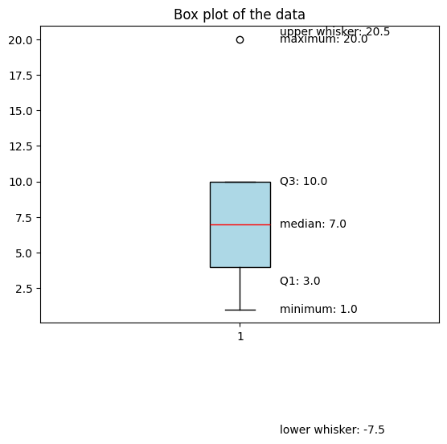

```python
import pandas as pd
import numpy as np
import matplotlib.pyplot as plt

# import data and sort it
data_original = np.array([2, 3, 7, 7, 10, 9, 7, 10, 6, 10, 3, 10, 20, 3, 10, 8, 5, 1, 5])
data_sorted = np.sort(data_original)
print("sorted data:", data_sorted)

# calculate the number of data points
n = len(data_sorted)
print("number of data points:", n)

# calculate the minimum and maximum
minimum = data_sorted[0]
maximum = data_sorted[-1]
print("minimum:", minimum)
print("maximum:", maximum)

# calculate the median
n = len(data_sorted)
if n % 2 == 0:
    median = (data_sorted[n//2 - 1] + data_sorted[n//2]) / 2
else:
    median = data_sorted[n//2]
print("median:", median)

# calculate Q1 and Q3
if n % 2 == 0:
    Q1 = np.median(data_sorted[:n//2])
    Q3 = np.median(data_sorted[n//2:])
else:
    Q1 = np.median(data_sorted[:n//2])
    Q3 = np.median(data_sorted[n//2+1:])
print("Q1:", Q1)
print("Q3:", Q3)

# calculate IQR
IQR = Q3 - Q1
print("IQR:", IQR)

# calculate lower whisker and upper whisker
lower_whisker = Q1 - 1.5 * IQR
upper_whisker = Q3 + 1.5 * IQR
print("lower whisker:", lower_whisker)
print("upper whisker:", upper_whisker)

# plot the boxplot
print("boxplot of the data:")
plt.boxplot(data_sorted,patch_artist=True, boxprops=dict(facecolor="lightblue"),medianprops=dict(color="red"),whiskerprops=dict(color="black"),capprops=dict(color="black"))
plt.text(1.1, median, f"median: {median:.1f}", va="center")
plt.text(1.1, minimum, f"minimum: {minimum:.1f}", va="center")
plt.text(1.1, maximum, f"maximum: {maximum:.1f}", va="center")
plt.text(1.1, Q1, f"Q1: {Q1:.1f}", va="center")
plt.text(1.1, Q3, f"Q3: {Q3:.1f}", va="center")
plt.text(1.1, lower_whisker, f"lower whisker: {lower_whisker:.1f}", va="center")
plt.text(1.1, upper_whisker, f"upper whisker: {upper_whisker:.1f}", va="center")
plt.title("Box plot of the data")
plt.show()
```

## Question 3

Python problem: Looking at the dataset Housing.csv. The variables are  
• medv: median home price in different neighborhoods  
• crim: per capita crime rate  
• rm: average number of rooms per dwelling  
• zn: proportion of large lots (zoned for > 25, 000 feet)  
• river: whether a home is near a river (0: No, 1: yes)  
• ptratio: pupil-teacher ratio by town  
Questions:  
a) Show first 8 rows of the dataset.  
b) Given the median and mean of medv.  
c) Calculate 1st and 3rd quantile of crim.  
d) Plot histogram of crime.  
e) On the same plot, draw histograms of medv near a river and not near a river, respectively.  
f) Provide correlation matrix and the corresponding heatmap for the dataset.  
g) Fit a density curve using 10 bins for medv.

```
data_Housing loaded successfully.
shape of the data: (506, 6)
first 8 rows of the data:
       crim    zn  river     rm  ptratio  medv
0  0.00632  18.0      0  6.575     15.3  24.0
1  0.02731   0.0      0  6.421     17.8  21.6
2  0.02729   0.0      0  7.185     17.8  34.7
3  0.03237   0.0      0  6.998     18.7  33.4
4  0.06905   0.0      0  7.147     18.7  36.2
5  0.02985   0.0      0  6.430     18.7  28.7
6  0.08829  12.5      0  6.012     15.2  22.9
7  0.14455  12.5      0  6.172     15.2  27.1
median of the 'medv' column: 21.20
mean of the 'medv' column: 22.53
Q1 of the 'crim' column: 0.08
Q3 of the 'crim' column: 3.68

 the histogram of the 'crim' column:
```

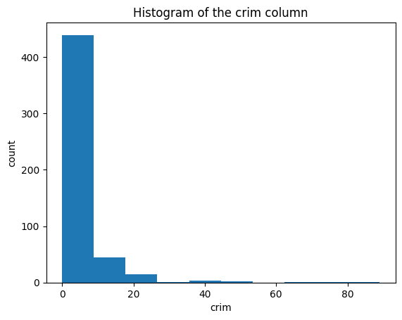

```
 the histogram of the medv column, near a river and not near a river, respectively:
```

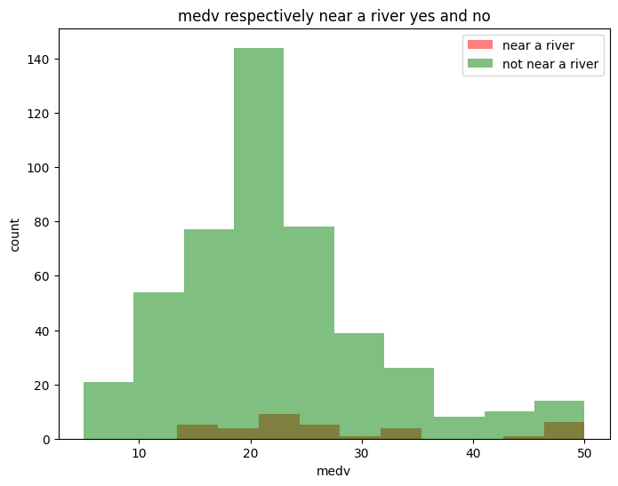

```
 Correlation matrix:
              crim        zn     river        rm   ptratio      medv
crim     1.000000 -0.200469 -0.055892 -0.219247  0.289946 -0.388305
zn      -0.200469  1.000000 -0.042697  0.311991 -0.391679  0.360445
river   -0.055892 -0.042697  1.000000  0.091251 -0.121515  0.175260
rm      -0.219247  0.311991  0.091251  1.000000 -0.355501  0.695360
ptratio  0.289946 -0.391679 -0.121515 -0.355501  1.000000 -0.507787
medv    -0.388305  0.360445  0.175260  0.695360 -0.507787  1.000000
```

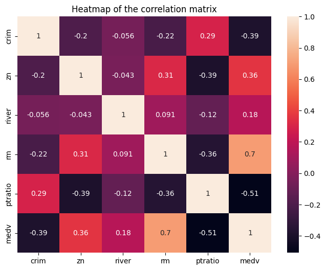

```
 the density plot of the 'medv' column:
```

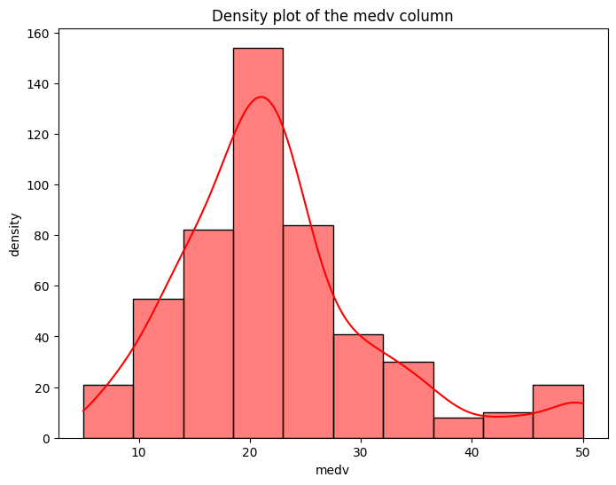

```python
import pandas as pd
import numpy as np
import matplotlib.pyplot as plt
import seaborn as sns

# Read the data from the csv file
data_Housing = pd.read_csv('Housing.csv')
try:
    data_Housing = pd.read_csv('Housing.csv')
    print("data_Housing loaded successfully.")
except FileNotFoundError:
    print("Error: 'Housing.csv' file not found.")

# show the shape of the data
print("shape of the data:", data_Housing.shape)

# show the first 8 rows of the data
print("first 8 rows of the data:\n", data_Housing.head(8))

# show the nedian and mean of the 'medv' column
medv_median = data_Housing['medv'].median()
medv_mean = data_Housing['medv'].mean()
print(f"median of the 'medv' column: {medv_median:.2f}")
print(f"mean of the 'medv' column: {medv_mean:.2f}")

# show the 1sd, 3sd quantiles of the 'crim' column
data_crim = data_Housing['crim']
data_crim_sorted = np.sort(data_crim)
n = len(data_crim_sorted)
if n % 2 == 0:
    Q1_crim = np.median(data_crim_sorted[:n//2])
    Q3_crim = np.median(data_crim_sorted[n//2:])
else:
    Q1_crim = np.median(data_crim_sorted[:n//2])
    Q3_crim = np.median(data_crim_sorted[(n//2)+1:])
print(f"Q1 of the 'crim' column: {Q1_crim:.2f}")
print(f"Q3 of the 'crim' column: {Q3_crim:.2f}")

# show the histogram of the 'crim' column
print("\n the histogram of the 'crim' column:")
plt.hist(data_crim, bins=10)
plt.xlabel('crim')
plt.ylabel('count')
plt.title('Histogram of the crim column')
plt.show()

#on the same plot, draw histograms of medv near a river and not near a river, respectively
print("\n the histogram of the medv column, near a river and not near a river, respectively:")
plt.figure(figsize=(8, 6))
river_yes = data_Housing[data_Housing['river'] == 1]['medv']
river_no = data_Housing[data_Housing['river'] == 0]['medv']
plt.hist(river_yes, bins=10, alpha=0.5, label='near a river', color='red')
plt.hist(river_no, bins=10, alpha=0.5, label='not near a river', color='green')
plt.xlabel('medv')
plt.ylabel('count')
plt.title('medv respectively near a river yes and no')
plt.legend()
plt.show()

#Provide correlation matrix and the corresponding heatmap for the dataset
corr_matrix = data_Housing.corr()
print("\n Correlation matrix:\n", corr_matrix)
plt.figure(figsize=(8, 6))
seaborn.heatmap(corr_matrix, annot=True)
plt.title('Heatmap of the correlation matrix')
plt.show()

#the density plot of the 'medv' column(10bins)
print("\n the density plot of the 'medv' column:")
plt.figure(figsize=(8, 6))
sns.histplot(data_Housing['medv'], bins=10, kde=True, color='red')
plt.xlabel('medv')
plt.ylabel('density')
plt.title('Density plot of the medv column')
plt.show()
```